# TUTORATO 7 - Esercitazione Data Analytics

Alessio Matessi - SM321657

Soluzione risolta: 06 - 07 - 2026

Riportare di seguito i comandi e le risposte necessarie allo svolgimento dell’esame. **I file html e Rmd entrambi vanno consegnati tramite moodle**.

1. Accertarsi che il file compili correttamente prima di iniziare l’esame
2. Compilare (e salvare!) spesso
3. Se non si riesce a risolvere l’errore di compilazione, utilizzare `eval = F` nel chunk (si veda l’esempio dove è stata inclusa la tilde per vostra convenienza)

```r
    ~
```

### PARTE 1: R

**Esercizio 1**:Scrivere una funzione che prenda in input tre vettori numerici della stessa lunghezza: `pressione`, `colesterolo` e `glicemia`.

La funzione, denominata `classifica_pazienti()` deve verificare che gli input siano corretti e poi:

- **Punto 1**: creare una variabile `Rischio` con tre livelli:
  - *Basso* se `pressione` è minore di 130, `colesterolo` è minore di 200 e `glicemia` è minore di 100;
  - *Medio* se almeno una ed al massimo una è fuori da una delle soglie fissate al punto precedente;
  - *Alto* se due condizioni o più sono fuori dalle medesime soglie.
- **Punto 2**: Restituire una lista composta da un dataframe contenente le variabili originali e la nuova variabile `Rischio` e dalla tabella delle frequenze assolute di `Rischio`

## ✏️ Svolgimento:

```r
## - PUNTO 1 -

# Scrivo la funzione che classifica i pazienti
classifica_pazienti <- function(pressione, colesterolo, glicemia)
{

  # Controllo che siano vettori numerici
  if (!is.numeric(pressione) ||
      !is.numeric(colesterolo) ||
      !is.numeric(glicemia))
  {
    stop("Errore: tutti gli input devono essere vettori numerici")
  }

  # Controllo che abbiano stessa lunghezza
  if (length(pressione) != length(colesterolo) ||
      length(pressione) != length(glicemia))
  {
    stop("Errore: i vettori devono avere la stessa lunghezza")
  }

  # In R TRUE=1 e FALSE=0. Sommo le condizioni per contare quante soglie sono superate
  out <- (pressione >= 130) + (colesterolo >= 200) + (glicemia >= 100)

  # Classificazione del rischio
  Rischio <- ifelse(out == 0, "Basso",
                    ifelse(out == 1, "Medio", "Alto"))

  # Trasformo in factor ordinato (Basso < Medio < Alto)
  Rischio <- factor(Rischio, levels = c("Basso", "Medio", "Alto"), ordered = TRUE)


  ## - PUNTO 2 -

  # Creo il dataframe con le variabili originali + Rischio
  df <- data.frame(pressione, colesterolo, glicemia, Rischio)

  # Tabella delle frequenze assolute di Rischio
  tabella <- table(Rischio)

  # Restituisco la lista
  return(list(dataframe = df, frequenze = tabella))
}


# Test della funzione
pressione_test <- c(120, 135, 145, 125)
colesterolo_test <- c(180, 210, 220, 190)
glicemia_test <- c(95, 98, 110, 105)

risultato_test <- classifica_pazienti(pressione_test, colesterolo_test, glicemia_test)

# Stampo il dataframe
risultato_test$dataframe
```

```
##   pressione colesterolo glicemia Rischio
## 1       120         180       95   Basso
## 2       135         210       98    Alto
## 3       145         220      110    Alto
## 4       125         190      105   Medio
```

```r
# Stampo le frequenze
risultato_test$frequenze
```

```
## Rischio
## Basso Medio  Alto
##     1     1     2
```

## 💥 Risposta

**Test con vettori di esempio**:

| pressione | colesterolo | glicemia | Rischio |
| --- | --- | --- | --- |
| 120 | 180 | 95 | Basso |
| 135 | 210 | 98 | Alto |
| 145 | 220 | 110 | Alto |
| 125 | 190 | 105 | Medio |

**Tabella frequenze assolute di Rischio**:

| Rischio | Frequenza |
| --- | --- |
| Basso | 1 |
| Medio | 1 |
| Alto | 2 |

- La funzione controlla correttamente gli input.
- La variabile `Rischio` viene classificata secondo le regole richieste.
- La lista restituita contiene il dataframe e la tabella delle frequenze.

### PARTE 2: Analisi dei Dati

**Esercizio 2**: Si considerino i dati contenuti nel file `salute.csv`. Si tratta di un dataset composto da dati raccolti su 387 pazienti, in particolare 8 (`Eta`, `BMI`, `Pressione`, `Colesterolo`, `AttivitaFisica`, `Glicemia`, `Sesso`, `Fumatore`).

- **Punto 1**: Calcolare media, mediana e deviazione standard della variabile `Pressione`;

## ✏️ Svolgimento:

```r
# Carico il dataset
dati <- read.csv("salute.csv", sep = "|")

# Preprocessing: rimuovo le righe con NA
dati <- na.omit(dati)

# Punto 1: media, mediana e deviazione standard di Pressione
media_pressione <- mean(dati$Pressione)
mediana_pressione <- median(dati$Pressione)
sd_pressione <- sd(dati$Pressione)

# Stampo i risultati
media_pressione
```

```
## [1] 145.7231
```

```r
mediana_pressione
```

```
## [1] 146
```

```r
sd_pressione
```

```
## [1] 15.89424
```

## 💥 Risposta

**Statistiche descrittive della variabile `Pressione`** (dopo rimozione NA):

| Statistica | Valore |
| --- | --- |
| **Media** | 145.72 mmHg |
| **Mediana** | 146 mmHg |
| **Deviazione standard** | 15.89 mmHg |

La pressione media dei pazienti è di circa **145.7 mmHg**, con una mediana molto simile (**146 mmHg**), indicando una distribuzione approssimativamente simmetrica. La deviazione standard di **15.89 mmHg** mostra una variabilità moderata intorno alla media.

- **Punto 2**: Costruire un boxplot di `Pressione` rispetto a `Fumatore`. Cosa si osserva?

## ✏️ Svolgimento:

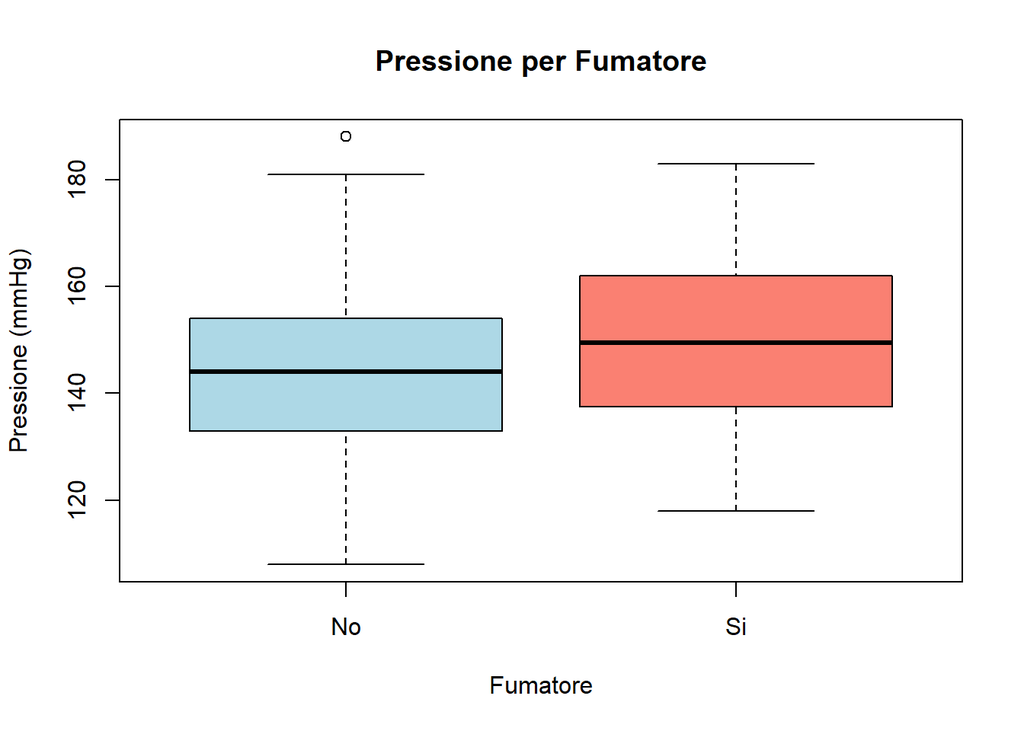

```r
# Carico il dataset e rimuovo i NA
dati <- read.csv("salute.csv", sep = "|")
dati <- na.omit(dati)

# Boxplot di Pressione rispetto a Fumatore
boxplot(Pressione ~ Fumatore,
        data = dati,
        col = c("lightblue", "salmon"),
        main = "Pressione per Fumatore",
        xlab = "Fumatore",
        ylab = "Pressione (mmHg)")
```

## 💥 Risposta

**Osservazioni**:

- I **fumatori** (Si) presentano una **pressione mediana più alta** rispetto ai non fumatori (No).
- La **variabilità** (larghezza dei box) è simile tra i due gruppi.
- Nel gruppo dei **non fumatori** è presente un **outlier** (un punto oltre il baffo superiore), indicando un individuo che non fuma ma ha pressione molto alta.
- Nel gruppo dei **fumatori** non si osservano outlier evidenti.

**Conclusione**: I fumatori tendono ad avere pressione più alta rispetto ai non fumatori. La presenza di un outlier nel gruppo dei non fumatori suggerisce che alcuni individui si discostano dal comportamento medio.

- **Punto 3**: Calcolare la matrice di correlazione tra le variabili quantitative. Quale coppia presenta la correlazione più alta?

## ✏️ Svolgimento:

```r
# Seleziono le variabili quantitative
dati_quant <- dati[, c("Eta", "BMI", "AttivitaFisica", "Pressione", "Colesterolo", "Glicemia")]

# Matrice di correlazione
matrice_cor <- cor(dati_quant)
matrice_cor
```

```
##                        Eta        BMI AttivitaFisica   Pressione Colesterolo
## Eta             1.00000000  0.3373496    -0.02054248  0.71496439  0.74683152
## BMI             0.33734957  1.0000000    -0.24547833  0.41897153  0.41502538
## AttivitaFisica -0.02054248 -0.2454783     1.00000000 -0.02562925 -0.06760503
## Pressione       0.71496439  0.4189715    -0.02562925  1.00000000  0.58801152
## Colesterolo     0.74683152  0.4150254    -0.06760503  0.58801152  1.00000000
## Glicemia        0.62621133  0.4375413    -0.30548007  0.48440697  0.49662998
##                  Glicemia
## Eta             0.6262113
## BMI             0.4375413
## AttivitaFisica -0.3054801
## Pressione       0.4844070
## Colesterolo     0.4966300
## Glicemia        1.0000000
```

```r
# Coppia con correlazione più alta
cor_senza_diag <- matrice_cor
diag(cor_senza_diag) <- NA
indice_max <- which.max(abs(cor_senza_diag))
riga <- row(cor_senza_diag)[indice_max]
colonna <- col(cor_senza_diag)[indice_max]

cat("Coppia con correlazione più alta:",
    rownames(matrice_cor)[riga], "e",
    colnames(matrice_cor)[colonna], "=",
    round(matrice_cor[riga, colonna], 4))
```

```
## Coppia con correlazione più alta: Colesterolo e Eta = 0.7468
```

## 💥 Risposta

**Matrice di correlazione** tra le variabili quantitative:

|  | Eta | BMI | AttivitaFisica | Pressione | Colesterolo | Glicemia |
| --- | --- | --- | --- | --- | --- | --- |
| **Eta** | 1.0000 | 0.3373 | -0.0205 | 0.7150 | 0.7468 | 0.6262 |
| **BMI** | 0.3373 | 1.0000 | -0.2455 | 0.4190 | 0.4150 | 0.4375 |
| **AttivitaFisica** | -0.0205 | -0.2455 | 1.0000 | -0.0256 | -0.0676 | -0.3055 |
| **Pressione** | 0.7150 | 0.4190 | -0.0256 | 1.0000 | 0.5880 | 0.4844 |
| **Colesterolo** | 0.7468 | 0.4150 | -0.0676 | 0.5880 | 1.0000 | 0.4966 |
| **Glicemia** | 0.6262 | 0.4375 | -0.3055 | 0.4844 | 0.4966 | 1.0000 |

**La coppia con correlazione più alta** è: **Eta** e **Colesterolo** con correlazione = **0.7468**

## ✏️ Svolgimento:

```r
# Carico il dataset e rimuovo i NA
dati <- read.csv("salute.csv", sep = "|")
dati <- na.omit(dati)

# Tabella di contingenza Sesso vs Fumatore
tabella <- table(dati$Sesso, dati$Fumatore)

# Test chi-quadrato
test_chi <- chisq.test(tabella)

# Output del test
test_chi
```

```
##
##  Pearson's Chi-squared test with Yates' continuity correction
##
## data:  tabella
## X-squared = 0.73957, df = 1, p-value = 0.3898
```

## 💥 Risposta

**Tabella di contingenza**:

[output not shown]

**Test χ²**:

- χ² = **0.7396**
- df = **1**
- p-value = **0.3898**

**Conclusione**:

Il p-value è **maggiore di 0.05**, quindi **non possiamo rifiutare l’ipotesi di indipendenza** tra `Sesso` e `Fumatore`. Le due variabili **non risultano associate** in modo statisticamente significativo: il fatto di essere maschio o femmina non sembra influenzare la probabilità di essere fumatore.

- **Punto 5**: Stimare il modello di regressione lineare con variabile di risposta `Pressione` e come regressori `Eta`, `BMI`, `Fumatore`:

## ✏️ Svolgimento:

```r
# Carico il dataset e rimuovo i NA
dati <- read.csv("salute.csv", sep = "|")
dati <- na.omit(dati)

# Modello di regressione lineare
modello <- lm(Pressione ~ Eta + BMI + Fumatore, data = dati)

# Output del modello
summary(modello)
```

```
##
## Call:
## lm(formula = Pressione ~ Eta + BMI + Fumatore, data = dati)
##
## Residuals:
##     Min      1Q  Median      3Q     Max
## -29.506  -6.920  -0.167   7.915  26.009
##
## Coefficients:
##             Estimate Std. Error t value Pr(>|t|)
## (Intercept) 92.08326    4.01847  22.915  < 2e-16 ***
## Eta          0.55394    0.03255  17.017  < 2e-16 ***
## BMI          1.10313    0.20244   5.449 1.01e-07 ***
## FumatoreSi   7.10173    1.23024   5.773 1.84e-08 ***
## ---
## Signif. codes:  0 '***' 0.001 '**' 0.01 '*' 0.05 '.' 0.1 ' ' 1
##
## Residual standard error: 10.23 on 321 degrees of freedom
## Multiple R-squared:  0.5895, Adjusted R-squared:  0.5856
## F-statistic: 153.6 on 3 and 321 DF,  p-value: < 2.2e-16
```

**5.1** Quali variabili sono statisticamente significative?

## 💥 Risposta:

**Modello di regressione lineare**:

$$\text{Pressione} = 92.08 + 0.55 \cdot
\text{Eta} + 1.10 \cdot \text{BMI} + 7.10 \cdot \text{FumatoreSi}$$

**Tutte le variabili sono statisticamente significative**:

| Variabile | p-value | Significatività |
| --- | --- | --- |
| **Eta** | < 2e-16 | *** |
| **BMI** | 1.01e-07 | *** |
| **FumatoreSi** | 1.84e-08 | *** |

Tutte hanno p-value **< 0.001**, quindi contribuiscono in modo significativo a spiegare la variabilità della pressione.

**5.2** Intepretare il coefficiente associato a `FumatoreSi`;

## 💥 Risposta:

**A parità di età e BMI**, un paziente fumatore ha una pressione **in media più alta di 7.10 mmHg** rispetto a un non fumatore.

- Baseline (categoria di riferimento): `FumatoreNo` (non fumatori).
- Il coefficiente positivo indica che il fumo è associato a un **aumento della pressione**.
- L’effetto è statisticamente significativo (p-value < 0.001).

  **5.3** Calcolare la percentuale di devianza spiegata dal modello;

## 💥 Risposta:

**R² = 0.5895** → il modello spiega il **58.95%** della variabilità totale di `Pressione`.

- **R² aggiustato** = 0.5856 (praticamente identico, indica che il modello non ha predittori ridondanti).
- Il modello è complessivamente significativo (p-value < 2.2e-16).

  **5.4** La pressione per un paziente fumatore con un’età di 50 anni ed un BMI di 27 prevista dal modello è circa:
- 150 mmHg
- 170 mmHg
- 157 mmHg
- 162 mmHg

## ✏️ Svolgimento:

## 💥 Risposta:

**5.5** Stimare il modello che ha la stessa variabile di risposta ma come predittore e l’interazione tra `BMI` e `Fumatore`; possiamo dire che l’effetto del BMI sulla pressione cambia tra fumatori e non fumatori? Perché?

## ✏️ Svolgimento:

## 💥 Risposta:

**5.6** Quale delle seguenti affermazioni è corretta?

- il termine `BMI:FumatoreSi` indica se l’effetto del BMI sulla pressione è diverso tra fumatori e non
- il termine `BMI:FumatoreSi` elimina l’effetto principale del BMI
- il termine `BMI:FumatoreSi` rappresenta la media del BMI nei fumatori
- il termine `BMI:FumatoreSi` indica la correlazione tra BMI e fumo

## ✏️ Svolgimento:

## 💥 Risposta:

- **Punto 6**:Standardizzare le variabili quantitative del dataset e salvarle in un oggetto `DataScaled`;

## ✏️ Svolgimento:

## 💥 Risposta:

- **Punto 7**:Applicare clustering gerarchico a `DataScaled` utilizzando il metodo di Ward:

## ✏️ Svolgimento:

## 💥 Risposta:

**7.1** Rappresentare il dendrogramma;

## ✏️ Svolgimento:

## 💥 Risposta:

**7.2** Costruire il plot delle altezze e, rispetto a tale grafico, scegliere un numero appropriato di cluster e motivarne il perché;

## ✏️ Svolgimento:

## 💥 Risposta:

**7.3** Riportare la numerosità di ciascun gruppo ottenuto;

## ✏️ Svolgimento:

## 💥 Risposta:

**7.4** Descrivere brevemente le caratteristiche dei cluster ottenuti considerando le medie delle variabili quantitative.

## ✏️ Svolgimento:

## 💥 Risposta:

- **Punto 8**:Applicare PCA alle variabili standardizzate:

## ✏️ Svolgimento:

## 💥 Risposta:

**8.1** Quanta variabilità viene spiegata dalle prime due componenti?

## ✏️ Svolgimento:

## 💥 Risposta:

**8.2** Costruire un grafico delle prime due componenti e colorarlo rispetto ai cluster ottenuti in precedenza; i gruppi sembrano ben separati?

## ✏️ Svolgimento:

## 💥 Risposta: